# Question

Matrices $A$ and $B$ are defined below.

$$A = \begin{bmatrix}
7 & 8\\
-3 & -9
\end{bmatrix}$$
$$B = \begin{bmatrix}
-6 & 2\\
-4 & 7
\end{bmatrix}$$

Find the [product](https://en.wikipedia.org/wiki/Matrix_multiplication) $C=AB$.

$AB=$

[output not shown]

## Answerlist

- -74
- -69
- 54
- 70
- -74
- -69
- 54
- 70
- -74
- -69
- 54
- 70
- -74
- -69
- 54
- 70

# Solution

We wish to do matrix multiplication:

$$\begin{bmatrix}
7 & 8\\
-3 & -9
\end{bmatrix}\begin{bmatrix}
-6 & 2\\
-4 & 7
\end{bmatrix}$$

The product matrix has 2 rows and 2 columns.

To find the product matrix’s value in row 1 and column 1, sum the products of corresponding elements of row 1 in matrix A and column 1 in matrix B.
$$C_{[1,1]}=(7)(-6)+(8)(-4)=-74$$

To find the product matrix’s value in row 1 and column 2, sum the products of corresponding elements of row 1 in matrix A and column 2 in matrix B.
$$C_{[1,2]}=(7)(2)+(8)(7)=70$$

To find the product matrix’s value in row 2 and column 1, sum the products of corresponding elements of row 2 in matrix A and column 1 in matrix B.
$$C_{[2,1]}=(-3)(-6)+(-9)(-4)=54$$

To find the product matrix’s value in row 2 and column 2, sum the products of corresponding elements of row 2 in matrix A and column 2 in matrix B.
$$C_{[2,2]}=(-3)(2)+(-9)(7)=-69$$

All of that work leads to the answer:

$$C = AB = \begin{bmatrix}
-74 & 70\\
54 & -69
\end{bmatrix}$$

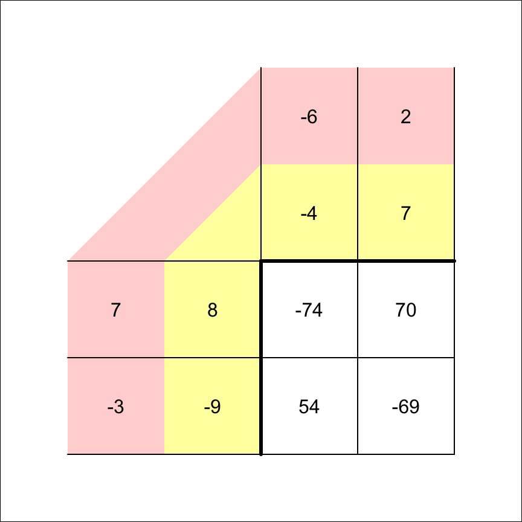

# Meta-information

extype: cloze exclozetype: schoice|schoice|schoice|schoice exsolution: 1000|0010|0001|0100 exname: mult_mats